# CompadecimentoEAbstenções

```python
import os
import pandas as pd
import numpy as np
import matplotlib.pyplot as plt
import seaborn as sns
pd.set_option('display.max_columns', None)
pd.set_option('display.max_rows', None)
```

```python
import os
os.environ["SPARK_HOME"] = "C:\spark-3.2.1-bin-hadoop2.7"
import findspark
findspark.init()
from pyspark.sql import SparkSession
spark = SparkSession.builder.master('local[*]').getOrCreate()
from pyspark.sql.functions import *
```

```python
PATH = "C:\\Users\\kevin\\Desktop\\Elecoes\\Dados_Eleitorado\\Abstencao\\CompadecimentoEAbstencao"
```

```python
df = spark.read.option("recursiveFileLookup","true").option("encoding", "ISO-8859-1").option("header","true").csv(PATH, sep = ';')
```

```python
df.limit(5).toPandas()
```

|  | DT_GERACAO | HH_GERACAO | ANO_ELEICAO | NR_TURNO | SG_UF | CD_MUNICIPIO | NM_MUNICIPIO | NR_ZONA | CD_GENERO | DS_GENERO | CD_ESTADO_CIVIL | DS_ESTADO_CIVIL | CD_FAIXA_ETARIA | DS_FAIXA_ETARIA | CD_GRAU_ESCOLARIDADE | DS_GRAU_ESCOLARIDADE | QT_APTOS | QT_COMPARECIMENTO | QT_ABSTENCAO | QT_COMPARECIMENTO_DEFICIENCIA | QT_ABSTENCAO_DEFICIENCIA | QT_COMPARECIMENTO_TTE | QT_ABSTENCAO_TTE |
| --- | --- | --- | --- | --- | --- | --- | --- | --- | --- | --- | --- | --- | --- | --- | --- | --- | --- | --- | --- | --- | --- | --- | --- |
| 0 | 10/05/2019 | 17:18:30 | 2014 | 1 | SC | 82554 | PINHEIRO PRETO | 47 | 4 | FEMININO | 3 | CASADO | 7579 | 75 a 79 anos | 2 | LÊ E ESCREVE | 1 | 0 | 1 | 0 | 0 | 0 | 0 |
| 1 | 10/05/2019 | 17:18:30 | 2014 | 1 | SC | 82554 | PINHEIRO PRETO | 47 | 4 | FEMININO | 3 | CASADO | 7579 | 75 a 79 anos | 3 | ENSINO FUNDAMENTAL INCOMPLETO | 38 | 16 | 22 | 0 | 0 | 0 | 0 |
| 2 | 10/05/2019 | 17:18:30 | 2014 | 1 | SC | 82554 | PINHEIRO PRETO | 47 | 4 | FEMININO | 3 | CASADO | 8589 | 85 a 89 anos | 3 | ENSINO FUNDAMENTAL INCOMPLETO | 5 | 0 | 5 | 0 | 0 | 0 | 0 |
| 3 | 10/05/2019 | 17:18:30 | 2014 | 1 | SC | 82554 | PINHEIRO PRETO | 47 | 4 | FEMININO | 5 | VIÚVO | 6064 | 60 a 64 anos | 4 | ENSINO FUNDAMENTAL COMPLETO | 1 | 1 | 0 | 0 | 0 | 0 | 0 |
| 4 | 10/05/2019 | 17:18:30 | 2014 | 1 | SC | 82554 | PINHEIRO PRETO | 47 | 4 | FEMININO | 5 | VIÚVO | 8589 | 85 a 89 anos | 1 | ANALFABETO | 1 | 0 | 1 | 0 | 0 | 0 | 0 |

```python
df = df.withColumn("DT_GERACAO",to_date(df.DT_GERACAO,"dd/MM/yyyy"))
df = df.withColumn("NR_TURNO",df.NR_TURNO.cast('int'))
df = df.withColumn("CD_MUNICIPIO",df.QT_APTOS.cast('int'))
df = df.withColumn("NR_ZONA",df.QT_APTOS.cast('int'))
df = df.withColumn("CD_GENERO",df.QT_APTOS.cast('int'))
df = df.withColumn("CD_ESTADO_CIVIL",df.QT_APTOS.cast('int'))
df = df.withColumn("CD_FAIXA_ETARIA",df.QT_APTOS.cast('int'))
df = df.withColumn("CD_GRAU_ESCOLARIDADE",df.QT_APTOS.cast('int'))
df = df.withColumn("QT_COMPARECIMENTO",df.QT_COMPARECIMENTO.cast('int'))
df = df.withColumn("QT_COMPARECIMENTO_DEFICIENCIA",df.QT_ABSTENCAO.cast('int'))
df = df.withColumn("QT_ABSTENCAO_DEFICIENCIA",df.QT_ABSTENCAO.cast('int'))
df = df.withColumn("QT_COMPARECIMENTO_TTE",df.QT_ABSTENCAO.cast('int'))
df = df.withColumn("QT_ABSTENCAO_TTE",df.QT_ABSTENCAO.cast('int'))
```

```python
df.dtypes
```

```
[('DT_GERACAO', 'date'),
 ('HH_GERACAO', 'string'),
 ('ANO_ELEICAO', 'string'),
 ('NR_TURNO', 'int'),
 ('SG_UF', 'string'),
 ('CD_MUNICIPIO', 'int'),
 ('NM_MUNICIPIO', 'string'),
 ('NR_ZONA', 'int'),
 ('CD_GENERO', 'int'),
 ('DS_GENERO', 'string'),
 ('CD_ESTADO_CIVIL', 'int'),
 ('DS_ESTADO_CIVIL', 'string'),
 ('CD_FAIXA_ETARIA', 'int'),
 ('DS_FAIXA_ETARIA', 'string'),
 ('CD_GRAU_ESCOLARIDADE', 'int'),
 ('DS_GRAU_ESCOLARIDADE', 'string'),
 ('QT_APTOS', 'string'),
 ('QT_COMPARECIMENTO', 'int'),
 ('QT_ABSTENCAO', 'string'),
 ('QT_COMPARECIMENTO_DEFICIENCIA', 'int'),
 ('QT_ABSTENCAO_DEFICIENCIA', 'int'),
 ('QT_COMPARECIMENTO_TTE', 'int'),
 ('QT_ABSTENCAO_TTE', 'int')]
```

```python
df.limit(5).toPandas()
```

|  | DT_GERACAO | HH_GERACAO | ANO_ELEICAO | NR_TURNO | SG_UF | CD_MUNICIPIO | NM_MUNICIPIO | NR_ZONA | CD_GENERO | DS_GENERO | CD_ESTADO_CIVIL | DS_ESTADO_CIVIL | CD_FAIXA_ETARIA | DS_FAIXA_ETARIA | CD_GRAU_ESCOLARIDADE | DS_GRAU_ESCOLARIDADE | QT_APTOS | QT_COMPARECIMENTO | QT_ABSTENCAO | QT_COMPARECIMENTO_DEFICIENCIA | QT_ABSTENCAO_DEFICIENCIA | QT_COMPARECIMENTO_TTE | QT_ABSTENCAO_TTE |
| --- | --- | --- | --- | --- | --- | --- | --- | --- | --- | --- | --- | --- | --- | --- | --- | --- | --- | --- | --- | --- | --- | --- | --- |
| 0 | 2019-05-10 | 17:18:30 | 2014 | 1 | SC | 1 | PINHEIRO PRETO | 1 | 1 | FEMININO | 1 | CASADO | 1 | 75 a 79 anos | 1 | LÊ E ESCREVE | 1 | 0 | 1 | 1 | 1 | 1 | 1 |
| 1 | 2019-05-10 | 17:18:30 | 2014 | 1 | SC | 38 | PINHEIRO PRETO | 38 | 38 | FEMININO | 38 | CASADO | 38 | 75 a 79 anos | 38 | ENSINO FUNDAMENTAL INCOMPLETO | 38 | 16 | 22 | 22 | 22 | 22 | 22 |
| 2 | 2019-05-10 | 17:18:30 | 2014 | 1 | SC | 5 | PINHEIRO PRETO | 5 | 5 | FEMININO | 5 | CASADO | 5 | 85 a 89 anos | 5 | ENSINO FUNDAMENTAL INCOMPLETO | 5 | 0 | 5 | 5 | 5 | 5 | 5 |
| 3 | 2019-05-10 | 17:18:30 | 2014 | 1 | SC | 1 | PINHEIRO PRETO | 1 | 1 | FEMININO | 1 | VIÚVO | 1 | 60 a 64 anos | 1 | ENSINO FUNDAMENTAL COMPLETO | 1 | 1 | 0 | 0 | 0 | 0 | 0 |
| 4 | 2019-05-10 | 17:18:30 | 2014 | 1 | SC | 1 | PINHEIRO PRETO | 1 | 1 | FEMININO | 1 | VIÚVO | 1 | 85 a 89 anos | 1 | ANALFABETO | 1 | 0 | 1 | 1 | 1 | 1 | 1 |

```python
df = df.drop("HH_GERACAO")
```

## Anáslie do país

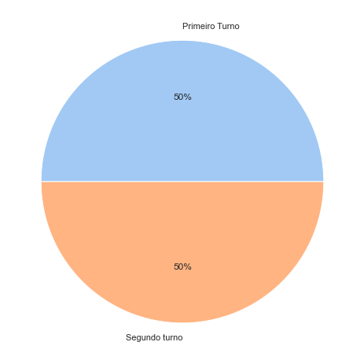

```python
turno = df.filter(df.ANO_ELEICAO == '2014').select('NR_TURNO').groupby('NR_TURNO').count().toPandas()

#define Seaborn color palette to use
colors = sns.color_palette('pastel')[0:5]

#create pie chart
plt.pie(turno['count'], labels = ['Primeiro Turno','Segundo turno'], colors = colors, autopct='%.0f%%')
plt.show()
```

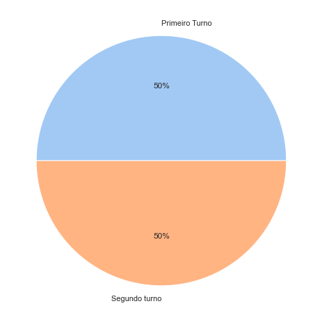

```python
turno = df.filter(df.ANO_ELEICAO == '2018').select('NR_TURNO').groupby('NR_TURNO').count().toPandas()
#define Seaborn color palette to use
colors = sns.color_palette('pastel')[0:5]

#create pie chart
plt.pie(turno['count'], labels = ['Primeiro Turno','Segundo turno'], colors = colors, autopct='%.0f%%')
plt.show()
```

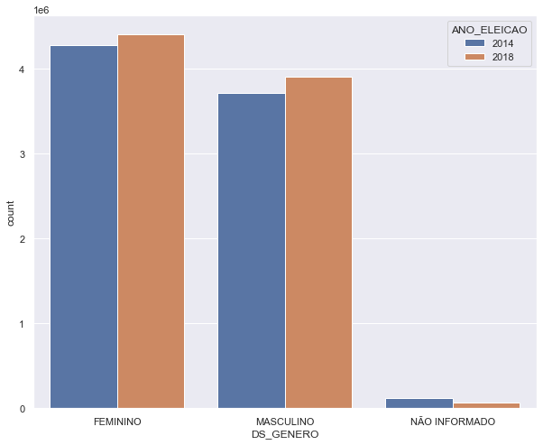

```python
sexo = df.select('ANO_ELEICAO','DS_GENERO').groupby('ANO_ELEICAO','DS_GENERO').count().toPandas()
plt.figure(figsize = (10,8))
sns.barplot(x='DS_GENERO',y='count',hue='ANO_ELEICAO',data=sexo)
```

[output not shown]

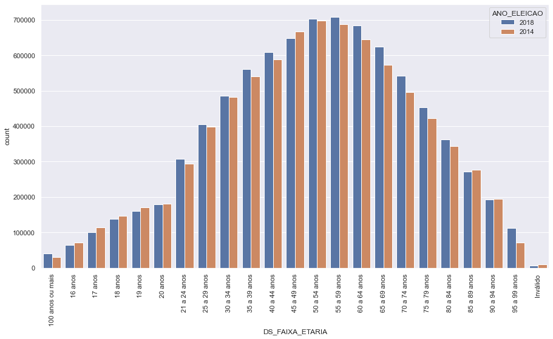

```python
idade = df.select('ANO_ELEICAO','DS_FAIXA_ETARIA').groupby('ANO_ELEICAO','DS_FAIXA_ETARIA').count().toPandas()
idade = idade.sort_values(by='DS_FAIXA_ETARIA')
plt.figure(figsize = (15,8))
ax = sns.barplot(x='DS_FAIXA_ETARIA',y='count',hue='ANO_ELEICAO',data=idade)
locs, labels = plt.xticks()
plt.setp(labels, rotation=90)
```

[output not shown]

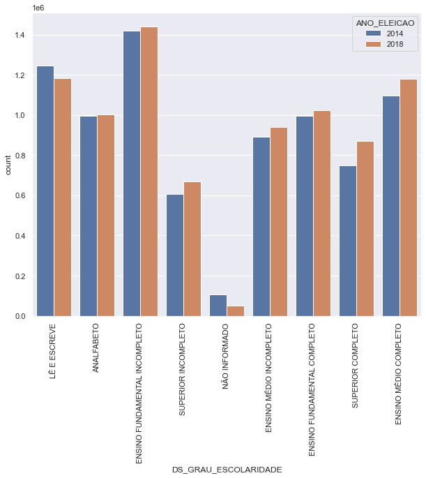

```python
escolaridade = df.select('ANO_ELEICAO','DS_GRAU_ESCOLARIDADE').groupby('ANO_ELEICAO','DS_GRAU_ESCOLARIDADE').count().toPandas()
plt.figure(figsize = (10,8))
ax = sns.barplot(x='DS_GRAU_ESCOLARIDADE',y='count',hue='ANO_ELEICAO',data=escolaridade)
locs, labels = plt.xticks()
plt.setp(labels, rotation=90)
```

### Eleitorado 2018

```
[None, None, None, None, None, None]
```

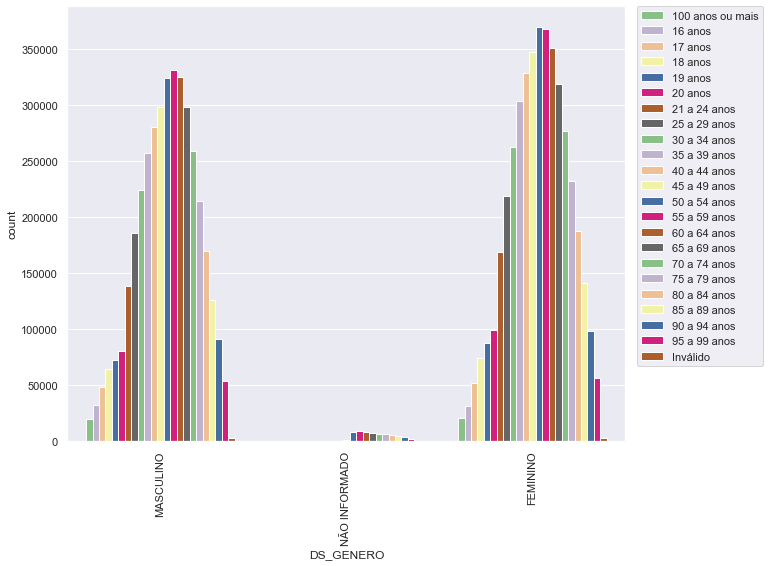

```python
idade_genero = df.filter(df.ANO_ELEICAO == '2018').select('DS_GENERO','DS_FAIXA_ETARIA')\
    .groupby('DS_GENERO','DS_FAIXA_ETARIA').count().toPandas()
idade_genero = idade_genero.sort_values(by='DS_FAIXA_ETARIA')
plt.figure(figsize = (10,8))
ax = sns.barplot(x='DS_GENERO',y='count',hue='DS_FAIXA_ETARIA',data=idade_genero,palette = 'Accent')
locs, labels = plt.xticks()
plt.legend(bbox_to_anchor=(1.02, 1), loc='upper left', borderaxespad=0)
plt.setp(labels, rotation=90)
```

```
[None, None, None, None, None, None]
```

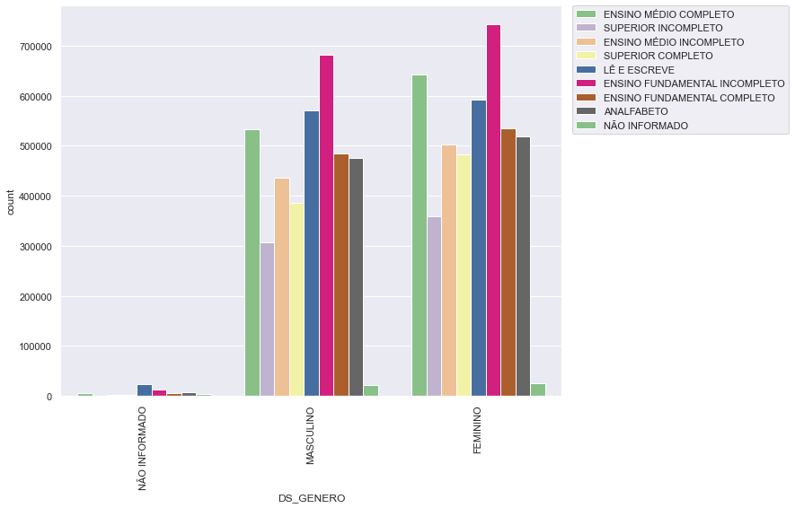

```python
genero_escolaridade = df.filter(df.ANO_ELEICAO == '2018').select('DS_GENERO','DS_GRAU_ESCOLARIDADE')\
    .groupby('DS_GENERO','DS_GRAU_ESCOLARIDADE').count().toPandas()
plt.figure(figsize = (10,8))
ax = sns.barplot(x='DS_GENERO',y='count',hue='DS_GRAU_ESCOLARIDADE',data=genero_escolaridade,palette = 'Accent')
locs, labels = plt.xticks()
plt.legend(bbox_to_anchor=(1.02, 1), loc='upper left', borderaxespad=0)
plt.setp(labels, rotation=90)
```

[output not shown]

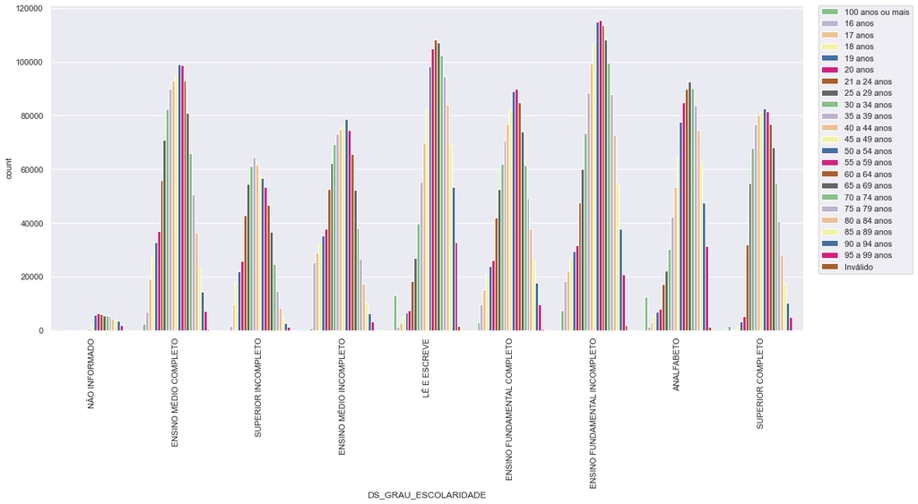

```python
idade_escolaridade = df.filter(df.ANO_ELEICAO == '2018').select('DS_FAIXA_ETARIA','DS_GRAU_ESCOLARIDADE')\
    .groupby('DS_FAIXA_ETARIA','DS_GRAU_ESCOLARIDADE').count().toPandas()
idade_escolaridade = idade_escolaridade.sort_values(by='DS_FAIXA_ETARIA')
plt.figure(figsize = (18,8))
ax = sns.barplot(x='DS_GRAU_ESCOLARIDADE',y='count',hue='DS_FAIXA_ETARIA',data=idade_escolaridade,palette = 'Accent')
locs, labels = plt.xticks()
plt.legend(bbox_to_anchor=(1.02, 1), loc='upper left', borderaxespad=0)
plt.setp(labels, rotation=90)
```

## Estudo de votantes que exerceram seu voto

Em esta parte do estudo se separo as pessoas que foram a votar, pois é o perfil de pessoa mais engajada com política ou que de fato vão exercer o voto. Para termos estadísticos e práticos são so votos que de fato elegeram os cargos públicos. Estes dados são a nível nacional. Dentro do perfil do votante maioritario está as seguintes características:

- A faixa etárea está entre 35-39 anos
- Tem ensino fundamental incompleto
- Geralmente são mulheres.
- Estado civil solteio(a)
- O estado com maior quantidade de votos é São Paulo

Posteriormente temos o perfil geral ou o que abarca maior quantidade de pessoas.

```
No handles with labels found to put in legend.
```

[output not shown]

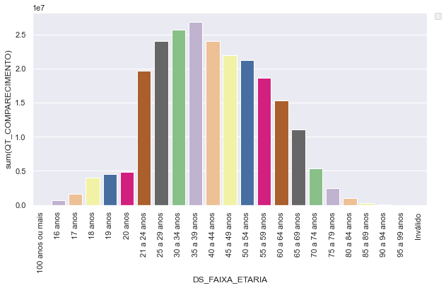

```python
idade_compadecimento = df.filter(df.ANO_ELEICAO == '2018').groupby('DS_FAIXA_ETARIA').sum("QT_COMPARECIMENTO").toPandas()
idade_compadecimento = idade_compadecimento.sort_values(by='DS_FAIXA_ETARIA')
plt.figure(figsize = (10,5))
ax = sns.barplot(x='DS_FAIXA_ETARIA',y='sum(QT_COMPARECIMENTO)',data=idade_compadecimento,palette = 'Accent')
locs, labels = plt.xticks()
plt.legend(bbox_to_anchor=(1.02, 1), loc='upper left', borderaxespad=0)
plt.setp(labels, rotation=90)
```

```
No handles with labels found to put in legend.
```

[output not shown]

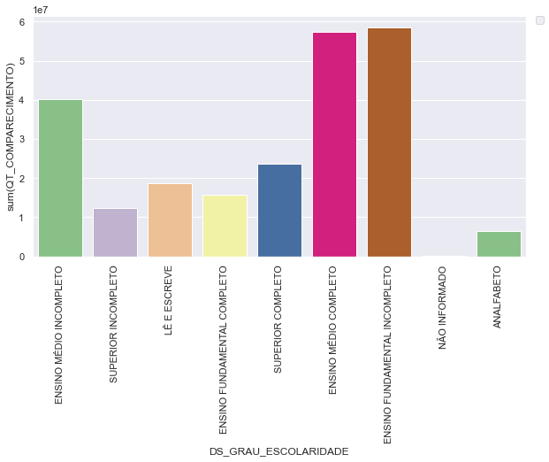

```python
escolaridade_compadecimento = df.filter(df.ANO_ELEICAO == '2018').groupby('DS_GRAU_ESCOLARIDADE').sum("QT_COMPARECIMENTO").toPandas()
plt.figure(figsize = (10,5))
ax = sns.barplot(x='DS_GRAU_ESCOLARIDADE',y='sum(QT_COMPARECIMENTO)',data=escolaridade_compadecimento,palette = 'Accent')
locs, labels = plt.xticks()
plt.legend(bbox_to_anchor=(1.02, 1), loc='upper left', borderaxespad=0)
plt.setp(labels, rotation=90)
```

```
No handles with labels found to put in legend.
```

```
[None, None, None, None, None, None]
```

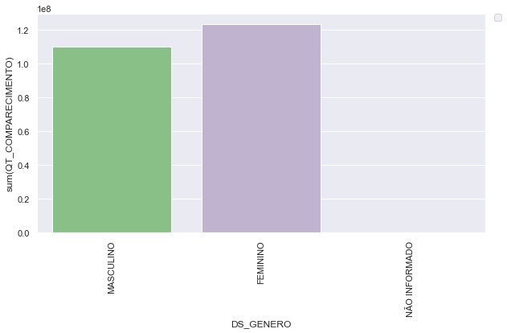

```python
sexo_compadecimento = df.filter(df.ANO_ELEICAO == '2018').groupby('DS_GENERO').sum("QT_COMPARECIMENTO").toPandas()
plt.figure(figsize = (10,5))
ax = sns.barplot(x='DS_GENERO',y='sum(QT_COMPARECIMENTO)',data=sexo_compadecimento,palette = 'Accent')
locs, labels = plt.xticks()
plt.legend(bbox_to_anchor=(1.02, 1), loc='upper left', borderaxespad=0)
plt.setp(labels, rotation=90)
```

```
No handles with labels found to put in legend.
```

```
[None, None, None, None, None, None, None, None, None, None, None, None]
```

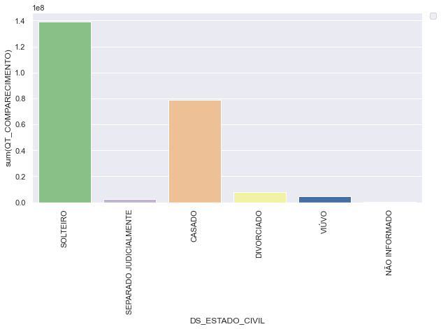

```python
estadocivil_compadecimento = df.filter(df.ANO_ELEICAO == '2018').groupby('DS_ESTADO_CIVIL').sum("QT_COMPARECIMENTO").toPandas()
plt.figure(figsize = (10,5))
ax = sns.barplot(x='DS_ESTADO_CIVIL',y='sum(QT_COMPARECIMENTO)',data=estadocivil_compadecimento,palette = 'Accent')
locs, labels = plt.xticks()
plt.legend(bbox_to_anchor=(1.02, 1), loc='upper left', borderaxespad=0)
plt.setp(labels, rotation=90)
```

```
No handles with labels found to put in legend.
```

[output not shown]

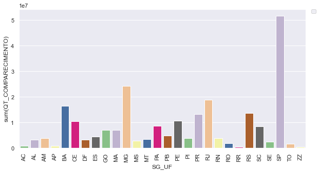

```python
estado_compadecimento = df.filter(df.ANO_ELEICAO == '2018').groupby('SG_UF').sum("QT_COMPARECIMENTO").toPandas()
estado_compadecimento = estado_compadecimento.sort_values(by='SG_UF')
plt.figure(figsize = (10,5))
ax = sns.barplot(x='SG_UF',y='sum(QT_COMPARECIMENTO)',data=estado_compadecimento,palette = 'Accent')
locs, labels = plt.xticks()
plt.legend(bbox_to_anchor=(1.02, 1), loc='upper left', borderaxespad=0)
plt.setp(labels, rotation=90)
```